# Limpeza de Dados

Os processos de limpeza e preparação de dados são muito importantes. Dados limpos, completos e organizados tornam as análises mais fáceis e confiáveis. Abaixo descrevemos alguns dos principais mecanismos para tratar dados que tenham algum problema.

Execute cada célula de código abaixo para ver o resultado.

## Leitura e análise inicial dos dados

```r
#importação de bibliotecas
library(dplyr)
library(tidyr)

# lê o arquivo CSV
df <- read.csv('../data/aluguel-com-erros.csv', header = T, sep=",", stringsAsFactors = FALSE)
```

O primeiro passo ao se analisar dados desconhecidos é visualizar algumas linhas de dados:

```r
head(df)
```

```
##   codigo                     endereco quartos suite area vaga aluguel
## 1     34 Rua Desembargador Westphalen       2     0   90    0     900
## 2    167            Rua Jose Loureiro       2     0   64    0     650
## 3   6784            Rua Jose Loureiro       2     0   81    0    1100
## 4     82           Rua Lourenço Pinto       2     0   50    0    1350
## 5   2970           Rua Lourenço Pinto       2     0   63    0    1300
## 6  34197        Alameda Doutor Muricy       2     0   80    1     900
##   condominio     data
## 1        371 11/10/17
## 2        428 15/07/17
## 3       1100 23/08/17
## 4        300 19/09/17
## 5        300 05/08/17
## 6        410 23/10/17
```

A função `summary` é útil para vermos quais colunas do DataFrame tiveram seus tipos de dados corretamente identificados pelo R. No caso abaixo já é possível identificar alguns problemas. As colunas *area, aluguel e condomínio* foram interpretadas como caracteres de texto (string) enquanto deveriam ser numéricas. A coluna *data* deveria ser do tipo `Date`.

```r
summary(df)
```

```
##      codigo           endereco            quartos       suite
##  Min.   :    24.0   Length:20          Min.   :1.0   Length:20
##  1st Qu.:   145.8   Class :character   1st Qu.:1.0   Class :character
##  Median :  4021.0   Mode  :character   Median :1.5   Mode  :character
##  Mean   : 31557.2                      Mean   :1.5
##  3rd Qu.: 36848.5                      3rd Qu.:2.0
##  Max.   :294579.0                      Max.   :2.0
##      area                vaga        aluguel           condominio
##  Length:20          Min.   :0.00   Length:20          Length:20
##  Class :character   1st Qu.:0.00   Class :character   Class :character
##  Mode  :character   Median :0.00   Mode  :character   Mode  :character
##                     Mean   :0.35
##                     3rd Qu.:1.00
##                     Max.   :1.00
##      data
##  Length:20
##  Class :character
##  Mode  :character
##
##
##
```

## Localizando e tratando valores inválidos

Valores inválidos ou não existentes podem ser convenientemente representados pelo valor NA (not available). Mas para que isto seja possível, é preciso indicar quais valores devem ser considerados NA. Uma rápida avaliação dos dados do csv (você pode editar o arquivo em um editor, por exemplo) mostra que diversos campos estão sem valor e alguns são marcados com o caracter `?`. Para que a leitura do arquivo reconheça os valores inválidos e ausentes como NA, podemos incluir o parâmetro `na.strings` como no exemplo abaixo.

```r
df <- read.csv('../data/aluguel-com-erros.csv', header = T, sep=",", stringsAsFactors = FALSE, na.strings=c("","NA", "?"))
df
```

```
##    codigo                       endereco quartos suite area vaga aluguel
## 1      34   Rua Desembargador Westphalen       2     0   90    0     900
## 2     167              Rua Jose Loureiro       2     0   64    0     650
## 3    6784              Rua Jose Loureiro       2     0   81    0    1100
## 4      82             Rua Lourenço Pinto       2     0   50    0    1350
## 5    2970             Rua Lourenço Pinto       2     0   63    0    1300
## 6   34197          Alameda Doutor Muricy       2     0   80    1     900
## 7    5072          Alameda Doutor Muricy       2     0   84    0    1100
## 8     469                           <NA>       1     0   30    0     550
## 9      24    R. Desembargador Westphalen       1     0   60    1     800
## 10     74 Avenida Visconde de Guarapuava       2     1  132    1    1800
## 11   9850 Avenida Visconde de Guarapuava       1     0   64    1     600
## 12  82343       Avenida Sete de Setembro       1     0   45    0     750
## 13  20802       Avenida Sete de Setembro       1     0   47    0     600
## 14    568               Rua Alferes Poli       1     0   43    0     600
```

[output cut: 27 more lines]

Com os NA representados adequadamente, podemos usar diversas funções que os referenciam. Por exemplo, abaixo usamos o teste `is.na` para identificar as linhas que contenham valores nulos em qualquer variável (coluna).

```r
df %>%
  filter_all(any_vars(is.na(.)))
```

```
##   codigo        endereco quartos suite area vaga aluguel condominio     data
## 1    469            <NA>       1     0   30    0     550        210 03/07/17
## 2  44803 Rua Rockefeller       2    NA   NA    1      NA         NA 19/07/17
```

O apartamento com código 44803 mostrado acima tem muitos campos vazios. Uma boa estratégia neste caso é eliminar esta linha. O comando abaixo define um novo DataFrame sem este apartamento.

```r
df_sem_nulos <- df %>%
  filter(codigo != '44803')

df_sem_nulos
```

```
##    codigo                       endereco quartos suite area vaga aluguel
## 1      34   Rua Desembargador Westphalen       2     0   90    0     900
## 2     167              Rua Jose Loureiro       2     0   64    0     650
## 3    6784              Rua Jose Loureiro       2     0   81    0    1100
## 4      82             Rua Lourenço Pinto       2     0   50    0    1350
## 5    2970             Rua Lourenço Pinto       2     0   63    0    1300
## 6   34197          Alameda Doutor Muricy       2     0   80    1     900
## 7    5072          Alameda Doutor Muricy       2     0   84    0    1100
## 8     469                           <NA>       1     0   30    0     550
## 9      24    R. Desembargador Westphalen       1     0   60    1     800
## 10     74 Avenida Visconde de Guarapuava       2     1  132    1    1800
## 11   9850 Avenida Visconde de Guarapuava       1     0   64    1     600
## 12  82343       Avenida Sete de Setembro       1     0   45    0     750
## 13  20802       Avenida Sete de Setembro       1     0   47    0     600
## 14    568               Rua Alferes Poli       1     0   43    0     600
```

[output cut: 25 more lines]

Se você quer eliminar as linhas com valores nulos em uma determinada coluna, basta usar o `drop_na()` especificando a coluna. Se quiser eliminar todas as linhas com valores nulos em qualquer coluna, use `drop_na()` sem especificar colunas.

```r
df %>% drop_na(endereco)
```

```
##    codigo                       endereco quartos suite area vaga aluguel
## 1      34   Rua Desembargador Westphalen       2     0   90    0     900
## 2     167              Rua Jose Loureiro       2     0   64    0     650
## 3    6784              Rua Jose Loureiro       2     0   81    0    1100
## 4      82             Rua Lourenço Pinto       2     0   50    0    1350
## 5    2970             Rua Lourenço Pinto       2     0   63    0    1300
## 6   34197          Alameda Doutor Muricy       2     0   80    1     900
## 7    5072          Alameda Doutor Muricy       2     0   84    0    1100
## 8      24    R. Desembargador Westphalen       1     0   60    1     800
## 9      74 Avenida Visconde de Guarapuava       2     1  132    1    1800
## 10   9850 Avenida Visconde de Guarapuava       1     0   64    1     600
## 11  82343       Avenida Sete de Setembro       1     0   45    0     750
## 12  20802       Avenida Sete de Setembro       1     0   47    0     600
## 13    568               Rua Alferes Poli       1     0   43    0     600
## 14 294579               Av. Silva Jardim       1     0   36    0     550
```

[output cut: 25 more lines]

```r
df_sem_nulos <- df_sem_nulos %>%
  mutate(endereco = replace_na(endereco, "desconhecido"))

df_sem_nulos
```

```
##    codigo                       endereco quartos suite area vaga aluguel
## 1      34   Rua Desembargador Westphalen       2     0   90    0     900
## 2     167              Rua Jose Loureiro       2     0   64    0     650
## 3    6784              Rua Jose Loureiro       2     0   81    0    1100
## 4      82             Rua Lourenço Pinto       2     0   50    0    1350
## 5    2970             Rua Lourenço Pinto       2     0   63    0    1300
## 6   34197          Alameda Doutor Muricy       2     0   80    1     900
## 7    5072          Alameda Doutor Muricy       2     0   84    0    1100
## 8     469                   desconhecido       1     0   30    0     550
## 9      24    R. Desembargador Westphalen       1     0   60    1     800
## 10     74 Avenida Visconde de Guarapuava       2     1  132    1    1800
## 11   9850 Avenida Visconde de Guarapuava       1     0   64    1     600
## 12  82343       Avenida Sete de Setembro       1     0   45    0     750
## 13  20802       Avenida Sete de Setembro       1     0   47    0     600
## 14    568               Rua Alferes Poli       1     0   43    0     600
```

[output cut: 25 more lines]

Podemos também fazer substituições de partes das *strings* no DataFrame. Por exemplo, podemos padronizar ruas e avenidas com as abreviações R. e Av. O código abaixo faz isto:

```r
library(stringr)

df_sem_nulos <- df_sem_nulos %>%
  mutate(endereco = str_replace(endereco, "Rua", "R.")) %>%
  mutate(endereco = str_replace(endereco, "Avenida", "Av."))

df_sem_nulos
```

```
##    codigo                    endereco quartos suite area vaga aluguel
## 1      34 R. Desembargador Westphalen       2     0   90    0     900
## 2     167            R. Jose Loureiro       2     0   64    0     650
## 3    6784            R. Jose Loureiro       2     0   81    0    1100
## 4      82           R. Lourenço Pinto       2     0   50    0    1350
## 5    2970           R. Lourenço Pinto       2     0   63    0    1300
## 6   34197       Alameda Doutor Muricy       2     0   80    1     900
## 7    5072       Alameda Doutor Muricy       2     0   84    0    1100
## 8     469                desconhecido       1     0   30    0     550
## 9      24 R. Desembargador Westphalen       1     0   60    1     800
## 10     74  Av. Visconde de Guarapuava       2     1  132    1    1800
## 11   9850  Av. Visconde de Guarapuava       1     0   64    1     600
## 12  82343        Av. Sete de Setembro       1     0   45    0     750
## 13  20802        Av. Sete de Setembro       1     0   47    0     600
## 14    568             R. Alferes Poli       1     0   43    0     600
```

[output cut: 25 more lines]

## Conversão de tipos

Como pode ser visto pela execução do método `str` abaixo, as colunas ainda possuem tipos incorretos. Precisamos então fazer a conversão manual dos tipos.

```r
str(df_sem_nulos)
```

```
## 'data.frame':    19 obs. of  9 variables:
##  $ codigo    : int  34 167 6784 82 2970 34197 5072 469 24 74 ...
##  $ endereco  : chr  "R. Desembargador Westphalen" "R. Jose Loureiro" "R. Jose Loureiro" "R. Lourenço Pinto" ...
##  $ quartos   : int  2 2 2 2 2 2 2 1 1 2 ...
##  $ suite     : int  0 0 0 0 0 0 0 0 0 1 ...
##  $ area      : int  90 64 81 50 63 80 84 30 60 132 ...
##  $ vaga      : int  0 0 0 0 0 1 0 0 1 1 ...
##  $ aluguel   : int  900 650 1100 1350 1300 900 1100 550 800 1800 ...
##  $ condominio: int  371 428 1100 300 300 410 382 210 120 520 ...
##  $ data      : chr  "11/10/17" "15/07/17" "23/08/17" "19/09/17" ...
```

Para uma coluna com datas, precisamos usar o `as.Date`. O componente `format` especifica o formato da data. `"%d/%m/%y"` representa datas como 23/04/67 enquanto `"%d-%m-%Y"` representa 23-04-1967.

```r
df_ajustado <- df_sem_nulos %>%
  mutate(data = as.Date(data, format= "%d/%m/%y"))

# Verificando nulos
df_ajustado %>%
  filter_all(any_vars(is.na(.)))
```

```
##   codigo             endereco quartos suite area vaga aluguel condominio data
## 1  82343 Av. Sete de Setembro       1     0   45    0     750        420 <NA>
```

Após converter a coluna para o tipo Date, temos ainda uma linha com um valor NA. Podemos ver os dados no DataFrame original para entender o problema:

```r
df %>% filter(codigo == 82343)
```

```
##   codigo                 endereco quartos suite area vaga aluguel condominio
## 1  82343 Avenida Sete de Setembro       1     0   45    0     750        420
##         data
## 1 janeiro 17
```

No resultado acima podemos ver que o valor original de data para o registro é “janeiro 17”. Precisamos então substituir este valor antes de fazer a conversão para data:

```r
df_sem_nulos <- df_sem_nulos %>%
  mutate(data = str_replace(data, 'janeiro 17', '01/01/17'))

df_sem_nulos
```

```
##    codigo                    endereco quartos suite area vaga aluguel
## 1      34 R. Desembargador Westphalen       2     0   90    0     900
## 2     167            R. Jose Loureiro       2     0   64    0     650
## 3    6784            R. Jose Loureiro       2     0   81    0    1100
## 4      82           R. Lourenço Pinto       2     0   50    0    1350
## 5    2970           R. Lourenço Pinto       2     0   63    0    1300
## 6   34197       Alameda Doutor Muricy       2     0   80    1     900
## 7    5072       Alameda Doutor Muricy       2     0   84    0    1100
## 8     469                desconhecido       1     0   30    0     550
## 9      24 R. Desembargador Westphalen       1     0   60    1     800
## 10     74  Av. Visconde de Guarapuava       2     1  132    1    1800
## 11   9850  Av. Visconde de Guarapuava       1     0   64    1     600
## 12  82343        Av. Sete de Setembro       1     0   45    0     750
## 13  20802        Av. Sete de Setembro       1     0   47    0     600
## 14    568             R. Alferes Poli       1     0   43    0     600
```

[output cut: 25 more lines]

Como substituímos o valor com problema, conseguimos converter corretamente a coluna:

```r
df_ajustado <- df_sem_nulos %>%
  mutate(data = as.Date(data, format= "%d/%m/%y"))

df_ajustado %>%
  filter_all(any_vars(is.na(.)))
```

```
## [1] codigo     endereco   quartos    suite      area       vaga       aluguel
## [8] condominio data
## <0 rows> (or 0-length row.names)
```

Agora podemos conferir os tipos e verificar que estão todos corretos:

```r
str(df_ajustado)
```

```
## 'data.frame':    19 obs. of  9 variables:
##  $ codigo    : int  34 167 6784 82 2970 34197 5072 469 24 74 ...
##  $ endereco  : chr  "R. Desembargador Westphalen" "R. Jose Loureiro" "R. Jose Loureiro" "R. Lourenço Pinto" ...
##  $ quartos   : int  2 2 2 2 2 2 2 1 1 2 ...
##  $ suite     : int  0 0 0 0 0 0 0 0 0 1 ...
##  $ area      : int  90 64 81 50 63 80 84 30 60 132 ...
##  $ vaga      : int  0 0 0 0 0 1 0 0 1 1 ...
##  $ aluguel   : int  900 650 1100 1350 1300 900 1100 550 800 1800 ...
##  $ condominio: int  371 428 1100 300 300 410 382 210 120 520 ...
##  $ data      : Date, format: "2017-10-11" "2017-07-15" ...
```

```r
df_ajustado <- df_ajustado %>%
  mutate_at(c("aluguel", "condominio"), as.numeric)

str(df_ajustado)
```

```
## 'data.frame':    19 obs. of  9 variables:
##  $ codigo    : int  34 167 6784 82 2970 34197 5072 469 24 74 ...
##  $ endereco  : chr  "R. Desembargador Westphalen" "R. Jose Loureiro" "R. Jose Loureiro" "R. Lourenço Pinto" ...
##  $ quartos   : int  2 2 2 2 2 2 2 1 1 2 ...
##  $ suite     : int  0 0 0 0 0 0 0 0 0 1 ...
##  $ area      : int  90 64 81 50 63 80 84 30 60 132 ...
##  $ vaga      : int  0 0 0 0 0 1 0 0 1 1 ...
##  $ aluguel   : num  900 650 1100 1350 1300 900 1100 550 800 1800 ...
##  $ condominio: num  371 428 1100 300 300 410 382 210 120 520 ...
##  $ data      : Date, format: "2017-10-11" "2017-07-15" ...
```

E podemos fazer ajustes, como corrigir os valores de aluguel de acordo com um índice de inflação:

```r
df_ajustado <- df_ajustado %>%
  mutate(aluguel = aluguel * 1.162)

head(df_ajustado)
```

```
##   codigo                    endereco quartos suite area vaga aluguel condominio
## 1     34 R. Desembargador Westphalen       2     0   90    0  1045.8        371
## 2    167            R. Jose Loureiro       2     0   64    0   755.3        428
## 3   6784            R. Jose Loureiro       2     0   81    0  1278.2       1100
## 4     82           R. Lourenço Pinto       2     0   50    0  1568.7        300
## 5   2970           R. Lourenço Pinto       2     0   63    0  1510.6        300
## 6  34197       Alameda Doutor Muricy       2     0   80    1  1045.8        410
##         data
## 1 2017-10-11
## 2 2017-07-15
## 3 2017-08-23
## 4 2017-09-19
## 5 2017-08-05
## 6 2017-10-23
```

Com todos os tipos convertidos corretamente, podemos aplicar funções estatísticas e exibir corretamente os valores em gráficos como mostrado abaixo:

```r
paste('Média do aluguel (dados sujos):', mean(df$aluguel))
```

```
## [1] "Média do aluguel (dados sujos): NA"
```

```r
paste('Média do aluguel (dados limpos): ', mean(df_ajustado$aluguel))
```

```
## [1] "Média do aluguel (dados limpos):  1040.29578947368"
```

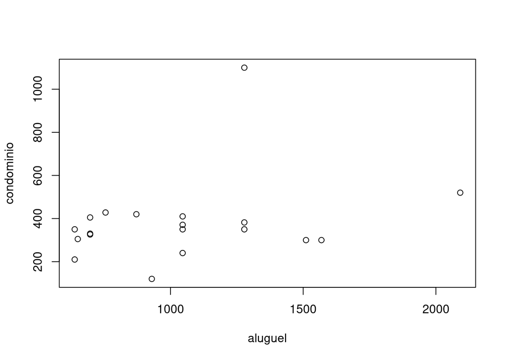

```r
plot(condominio ~ aluguel, data=df_ajustado)
```

## Identificando outliers

Outliers são valores fora da faixa esperada para uma observação. Um forma conveniente de identificar outliers é usando BoxPlots. Abaixo podemos perceber que existem dois valores de condomínio fora do que seria esperado (mostrados como círculos abaixo e acima da caixa).

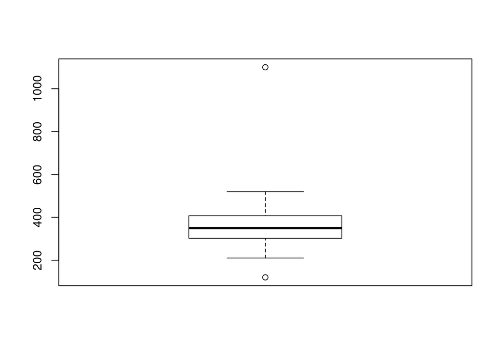

```r
boxplot(df_ajustado$condominio)
```

Outra forma de identificar outliers é calcular os *z-scores* para uma variável. O z-score fornece informação sobre o quão inesperado um valor é considerando os demais valores presentes. Abaixo calculamos os z-scores para a variável condomínio. Veja que um valor ‘inesperado’ é o 120 com z-score -1.3, indicando que é um valor mais baixo que o esperado. O outro outlier é o de condomínio 1100 com z-score 3.7 indicando que está muito acima do esperado. Em geral valores de z-score abaixo de -3 e acima de +3 são fortes candidados a serem outliers.

```r
df_ajustado %>%
  mutate(condominio_zscore = (condominio - mean(condominio))/sd(condominio)) %>%
  arrange(condominio_zscore)
```

```
##    codigo                    endereco quartos suite area vaga aluguel
## 1      24 R. Desembargador Westphalen       1     0   60    1  929.60
## 2     469                desconhecido       1     0   30    0  639.10
## 3    2381              R. Rockefeller       2     0   54    0 1045.80
## 4      82           R. Lourenço Pinto       2     0   50    0 1568.70
## 5    2970           R. Lourenço Pinto       2     0   63    0 1510.60
## 6   59375            Av. Silva Jardim       1     0   33    0  650.72
## 7    9850  Av. Visconde de Guarapuava       1     0   64    1  697.20
## 8     568             R. Alferes Poli       1     0   43    0  697.20
## 9  294579            Av. Silva Jardim       1     0   36    0  639.10
## 10     80 R. Desembargador Westphalen       1     0   80    1 1045.80
## 11  66490 R. Desembargador Westphalen       1     0   80    1 1278.20
## 12     34 R. Desembargador Westphalen       2     0   90    0 1045.80
## 13   5072       Alameda Doutor Muricy       2     0   84    0 1278.20
## 14  20802        Av. Sete de Setembro       1     0   47    0  697.20
```

[output cut: 25 more lines]

Uma possibilidade para eliminar o valor que está muito acima seria excluir a linha que o contém. O problema disso é que perderíamos todos os dados da linha, que inclui dados aparentemente corretos. Uma forma de manter os dados corretos e ao mesmo tempo minimizar a influência do valor incorreto é substituir o valor incorreto pela média dos demais valores para a variável, como fazemos abaixo. Veja que agora o valor de condomínio para a linha problemática é 379.84.

```r
df_ajustado <- df_ajustado %>%
  mutate(condominio = replace(condominio, condominio == 1100, mean(condominio)))

df_ajustado
```

```
##    codigo                    endereco quartos suite area vaga aluguel
## 1      34 R. Desembargador Westphalen       2     0   90    0 1045.80
## 2     167            R. Jose Loureiro       2     0   64    0  755.30
## 3    6784            R. Jose Loureiro       2     0   81    0 1278.20
## 4      82           R. Lourenço Pinto       2     0   50    0 1568.70
## 5    2970           R. Lourenço Pinto       2     0   63    0 1510.60
## 6   34197       Alameda Doutor Muricy       2     0   80    1 1045.80
## 7    5072       Alameda Doutor Muricy       2     0   84    0 1278.20
## 8     469                desconhecido       1     0   30    0  639.10
## 9      24 R. Desembargador Westphalen       1     0   60    1  929.60
## 10     74  Av. Visconde de Guarapuava       2     1  132    1 2091.60
## 11   9850  Av. Visconde de Guarapuava       1     0   64    1  697.20
## 12  82343        Av. Sete de Setembro       1     0   45    0  871.50
## 13  20802        Av. Sete de Setembro       1     0   47    0  697.20
## 14    568             R. Alferes Poli       1     0   43    0  697.20
```

[output cut: 25 more lines]

## Escrevendo os dados limpos no disco

Para salvar os dados limpos em um arquivo, usamos a função `write.csv`, como no exemplo abaixo:

```r
write.csv(df_ajustado, file = '../data/aluguel-limpo.csv')
```